# Accenture_1

## Load data

```python
import pandas as pd

# Load data
customer_orders_df = pd.read_csv('https://storage.googleapis.com/datalynn-datasets/interview-challenge/finance/Accenture_1/orders.csv')
product_reviews_df = pd.read_csv('https://storage.googleapis.com/datalynn-datasets/interview-challenge/finance/Accenture_1/reviews.csv')
```

## 3. Questions for the Data Challenge

### 1. Data Manipulation

**Question**:

In the `orders.csv` table, for each customer, can you find out the total number of orders placed by them and also rank these customers based on the total quantity of items they've ordered? Consider using a window function to achieve this.

**Answer**

```python
import sqlite3
import pandas as pd
from dateutil.parser import parse

# Load datasets into SQLite database
conn = sqlite3.connect('telecom_data.db')
customer_orders_df.to_sql('customer_orders_df', conn, if_exists='replace', index=False)
product_reviews_df.to_sql('product_reviews_df', conn, if_exists='replace', index=False)
```

```
1000
```

```python
query = """
SELECT CustomerID,
       COUNT(OrderID) AS TotalOrders,
       SUM(Quantity) AS TotalQuantity,
       RANK() OVER (ORDER BY SUM(Quantity) DESC) AS RankBasedOnQuantity
FROM customer_orders_df
GROUP BY CustomerID;
"""

result = pd.read_sql_query(query, conn)
result
```

|  | CustomerID | TotalOrders | TotalQuantity | RankBasedOnQuantity |
| --- | --- | --- | --- | --- |
| 0 | 174 | 10 | 36 | 1 |
| 1 | 187 | 11 | 33 | 2 |
| 2 | 165 | 10 | 33 | 2 |
| 3 | 83 | 11 | 33 | 2 |
| 4 | 52 | 10 | 33 | 2 |
| ... | ... | ... | ... | ... |
| 195 | 194 | 1 | 3 | 196 |
| 196 | 74 | 2 | 3 | 196 |
| 197 | 45 | 2 | 3 | 196 |
| 198 | 156 | 1 | 2 | 199 |
| 199 | 64 | 1 | 2 | 199 |

200 rows × 4 columns

**Question**:

We have a hypothesis that customers who order in larger quantities might give lower review scores due to heightened expectations or increased likelihood of issues with larger orders. Can you explore this by segmenting customers based on the total quantity of their orders and comparing the average review scores in each segment?

**Answer**

```python
query = """
-- Joining the orders and reviews tables on the common CustomerID and ProductID fields
WITH orders_reviews AS (
  SELECT o.CustomerID, o.ProductID, o.Quantity, r.ReviewScore
  FROM customer_orders_df o
  JOIN product_reviews_df r ON o.CustomerID = r.CustomerID AND o.ProductID = r.ProductID
),

-- Calculating total quantity ordered by each customer
customer_total_quantity AS (
  SELECT CustomerID, SUM(Quantity) AS TotalQuantity
  FROM orders_reviews
  GROUP BY CustomerID
),

-- Dividing customers into segments based on their total quantity ordered
customer_segments AS (
  SELECT CustomerID,
    CASE
      WHEN TotalQuantity <= 100 THEN 'Low Quantity'
      WHEN TotalQuantity <= 500 THEN 'Medium Quantity'
      ELSE 'High Quantity'
    END AS QuantitySegment
  FROM customer_total_quantity
)

-- Calculating average review scores within each segment
SELECT QuantitySegment, AVG(r.ReviewScore) AS AvgReviewScore
FROM orders_reviews r
JOIN customer_segments s ON r.CustomerID = s.CustomerID
GROUP BY QuantitySegment;
"""

result = pd.read_sql_query(query, conn)
result
```

|  | QuantitySegment | AvgReviewScore |
| --- | --- | --- |
| 0 | Low Quantity | 3.60987 |

### 2. Feature Engineering

**Question:**

Based on the `ReviewScore`, we might categorize customers into different satisfaction levels. How would you create this new categorical feature from the `ReviewScore`? What are the potential implications and uses of this new feature for our marketing efforts?

**Answer**

```python
# Define a function to categorize review scores
def categorize_review(score):
    if score < 3:
        return 'Dissatisfied'
    elif score == 3:
        return 'Neutral'
    else:
        return 'Satisfied'

# Apply the function to the 'ReviewScore' column
product_reviews_df['SatisfactionLevel'] = product_reviews_df['ReviewScore'].apply(categorize_review)
```

**Question:**

How could we quantify the customer's purchasing frequency? What kind of feature engineering would you propose to create a feature that represents this information? What potential insights could this feature offer?

**Answer**

```python
# Calculate the number of orders per customer
customer_frequency = customer_orders_df.groupby('CustomerID')['OrderID'].nunique()

# Map this information back to the original DataFrame
customer_orders_df['OrderFrequency'] = customer_orders_df['CustomerID'].map(customer_frequency)
```

**Question:**

Our dataset includes dates of order placement, delivery, and review submission. Can you think of ways to transform these raw dates into useful features that might affect a customer's review score? For instance, could the time taken for delivery or the time gap between delivery and review submission have an impact on the customer's satisfaction?

**Answer**

```python
import pandas as pd

# Read the csv files
orders_df = pd.read_csv('https://storage.googleapis.com/datalynn-datasets/interview-challenge/finance/Accenture_1/orders.csv', parse_dates=['OrderDate', 'DeliveryDate'])
reviews_df = pd.read_csv('https://storage.googleapis.com/datalynn-datasets/interview-challenge/finance/Accenture_1/reviews.csv', parse_dates=['ReviewDate'])

# Merge the two dataframes on 'CustomerID' and 'ProductID'
df = pd.merge(orders_df, reviews_df, on=['CustomerID', 'ProductID'])

# Create 'DeliveryDuration' feature as difference in days
df['DeliveryDuration'] = (df['DeliveryDate'] - df['OrderDate']).dt.days

# Create 'ReviewDelay' feature as difference in days
df['ReviewDelay'] = (df['ReviewDate'] - df['DeliveryDate']).dt.days
```

### 3. Machine Learning Modeling

**Question:**

In the case that our review scores are heavily skewed, with far more high-scoring reviews than low-scoring ones, this can create challenges in training a model. How would you tackle this issue during model selection and optimization? Please discuss potential strategies and their implications.

**Answer:**

```python
import pandas as pd
from sklearn.preprocessing import StandardScaler, OneHotEncoder
from sklearn.compose import ColumnTransformer
from sklearn.pipeline import Pipeline
from sklearn.ensemble import RandomForestClassifier
from sklearn.model_selection import train_test_split
from sklearn.metrics import classification_report
from imblearn.over_sampling import SMOTE

# And these are the numerical ones
numerical_features = ['Quantity']

# And these are the datetime features
datetime_features = ['OrderDate', 'DeliveryDate', 'ReviewDate']

# Define preprocessing for numeric columns (scale them)
numeric_transformer = Pipeline(steps=[
    ('scaler', StandardScaler())])

# Define preprocessing for categorical columns (encode them)
categorical_transformer = Pipeline(steps=[
    ('onehot', OneHotEncoder(handle_unknown='ignore'))])

# Combine preprocessing steps
preprocessor = ColumnTransformer(
    transformers=[
        ('num', numeric_transformer, numerical_features)],
        remainder='passthrough')

# Create preprocessing and training pipeline
pipeline = Pipeline(steps=[('preprocessor', preprocessor),
                           ('classifier', RandomForestClassifier())])

# Separate input features and target
y = df.ReviewScore-1
X = df.drop(columns=['ReviewScore', 'DeliveryDate', 'OrderDate', 'ReviewDate', 'OrderID', 'CustomerID', 'ProductID', 'ReviewID'], axis=1)

# Setting up testing and training sets
X_train, X_test, y_train, y_test = train_test_split(X, y, test_size=0.25, random_state=27)

# Resample data to handle class imbalance
sm = SMOTE(random_state=27)
X_train, y_train = sm.fit_resample(X_train, y_train)

# Fit the model
pipeline.fit(X_train, y_train)

# Make predictions
preds = pipeline.predict(X_test)

# Add 1 back to your predictions for interpretability
preds = preds + 1
y_test = y_test + 1

# Show classification report
print(classification_report(y_test, preds, zero_division=1))
```

```
              precision    recall  f1-score   support

           1       0.10      0.20      0.13        25
           2       0.09      0.15      0.12        26
           3       0.17      0.20      0.19        49
           4       0.30      0.26      0.28        74
           5       0.38      0.22      0.28        95

    accuracy                           0.22       269
   macro avg       0.21      0.21      0.20       269
weighted avg       0.27      0.22      0.23       269
```

**Question:**

The model seems to have difficulty in correctly classifying classes 1, 2 and 3. What do you think could be contributing to this issue? How would you go about investigating the causes?

**Answer:**

```
[0.08099971 0.4315451  0.48745519]
```

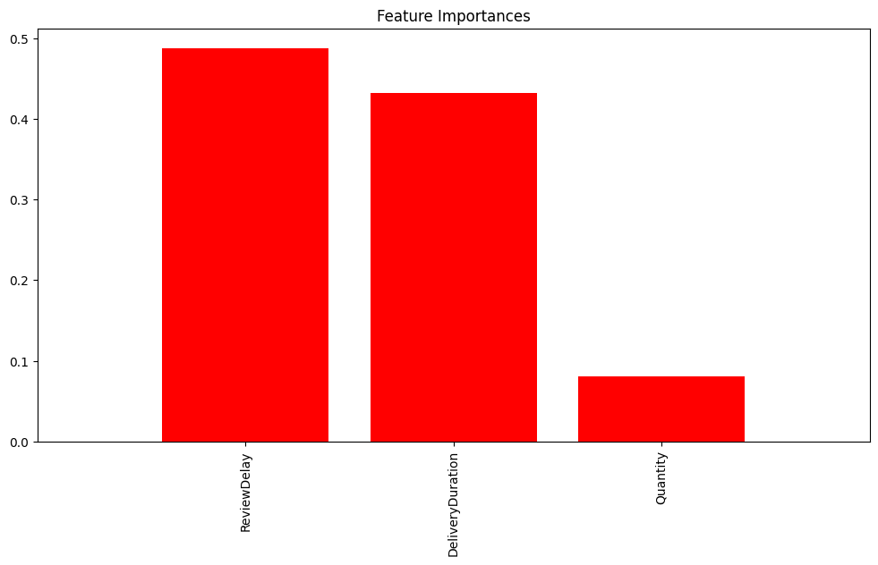

```
SVC Score: 0.0
XGBClassifier Score: 0.12267657992565056
```

```python
import matplotlib.pyplot as plt
from sklearn.inspection import permutation_importance
import numpy as np

# Get feature names
feature_names = X_train.columns

# Get Feature Importance
importances = pipeline.named_steps['classifier'].feature_importances_
print(importances)
indices = np.argsort(importances)[::-1]

# Create a mapping of feature indices to feature names
index_to_name_mapping = {index: feature_name for index, feature_name in enumerate(feature_names)}

# Convert indices to feature names
named_indices = [index_to_name_mapping[index] for index in indices]

# Plot the Feature Importance
plt.figure(figsize=(12,6))
plt.title("Feature Importances")
plt.bar(range(len(importances)), importances[indices], color="r", align="center")
plt.xticks(range(len(importances)), named_indices, rotation='vertical')
plt.xlim([-1, len(importances)])
plt.show()

# Evaluate Other Models
from sklearn.svm import SVC
from xgboost import XGBClassifier

for Model in [SVC, XGBClassifier]:
    model = Model()
    model.fit(X_train, y_train)
    print(f"{Model.__name__} Score: {model.score(X_test, y_test)}")
```

### Business Insight

1. Assuming the machine learning model has identified some customers as potentially valuable, how would you suggest the marketing team to leverage this information for optimizing marketing efforts?
2. The model has determined that certain consulting services are highly valued by clients, leading to higher satisfaction scores. How would you suggest the consulting team leverage this information to improve client relations and service offerings?
3. Our model found that clients who utilized a combination of services tend to have higher satisfaction scores. How can this information be used to cross-sell our services and improve overall client satisfaction?